# Final Report SP19 Time Series

Colin Thornburg

April 28, 2019

# Final Paper

## Data Set for package: astsa - U.S. Monthly Live Births

### Data Description:

This dataset is provided under the ASTSA package. It contains a total of 373 observations and is a Time Series object that contains the monthly live births (adjusted) in thousands in the US from 1948 - 1979.

see https://www.rdocumentation.org/packages/astsa/versions/1.8/topics/birth.

Some summary statistics, class, frequency, start/end of the dataset, and the variation (The variance is a numerical measure of how the data values is dispersed around the mean)

```r
library(astsa)
summary(birth)
```

```
##    Min. 1st Qu.  Median    Mean 3rd Qu.    Max.
##   238.0   284.0   310.0   310.9   336.0   399.0
```

```r
class(birth)
```

```
## [1] "ts"
```

```r
mean(birth)
```

```
## [1] 310.9088
```

```r
sd(birth)
```

```
## [1] 35.2506
```

```r
min(birth)
```

```
## [1] 238
```

```r
max(birth)
```

```
## [1] 399
```

```r
frequency(birth)
```

```
## [1] 12
```

```r
start(birth)
```

```
## [1] 1948    1
```

```r
end(birth)
```

```
## [1] 1979    1
```

## birth Basic Plot

Basic Plot of birth time series data:

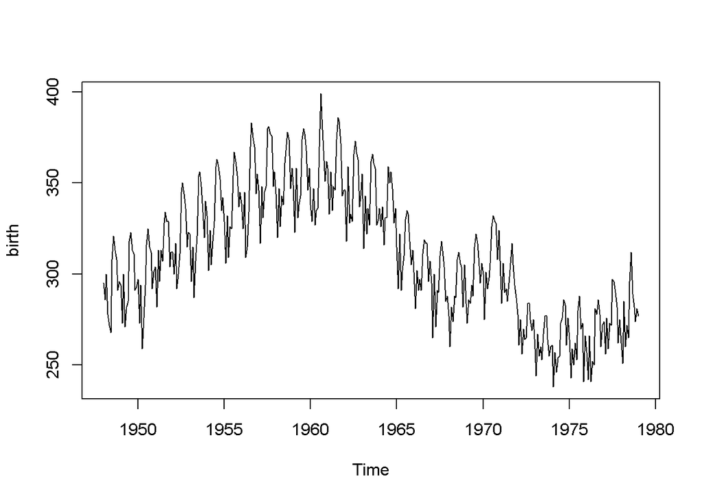

## Data Exploration

Histogram

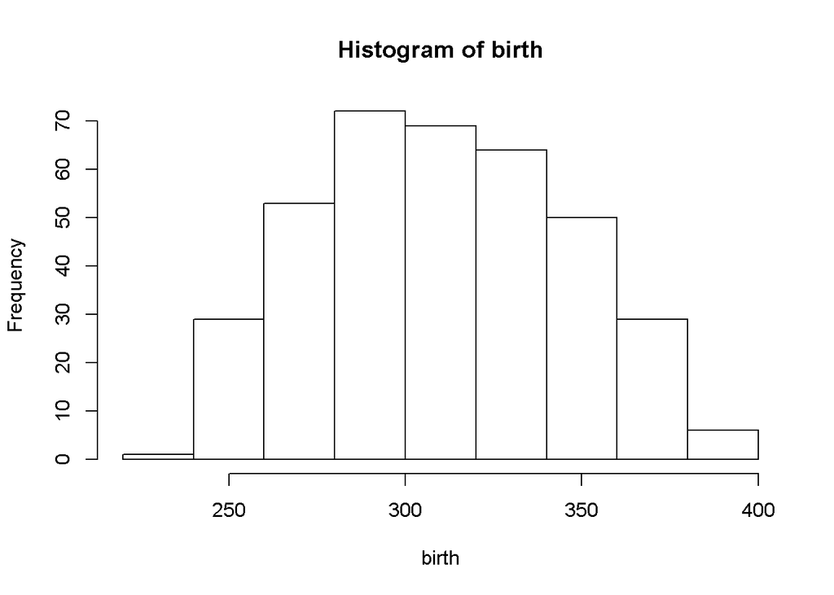

Boxplot across months

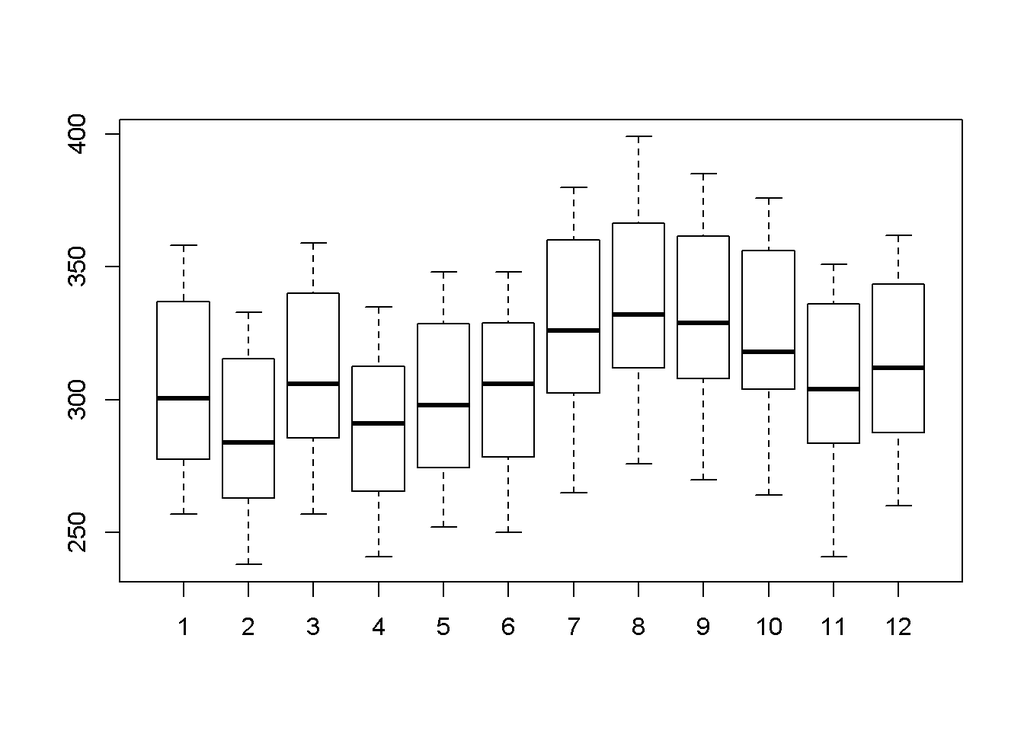

TS Plot with abline

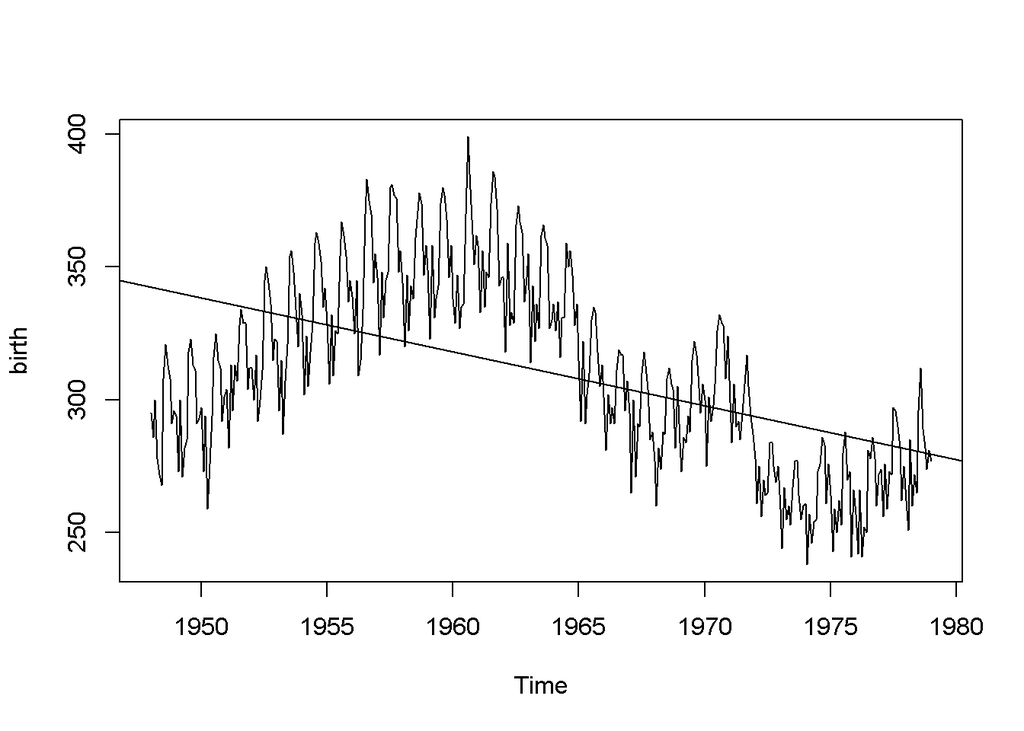

The overall trend of live birth is decreasing from 1949 - 1979. Live births seem to have some seasonality during the late summer/early fall months. In order to remove this seasonality component, the data will need to be de-trended by using a moving average. A log transformation does not appear to be needed as variance does not appear to increase with time.

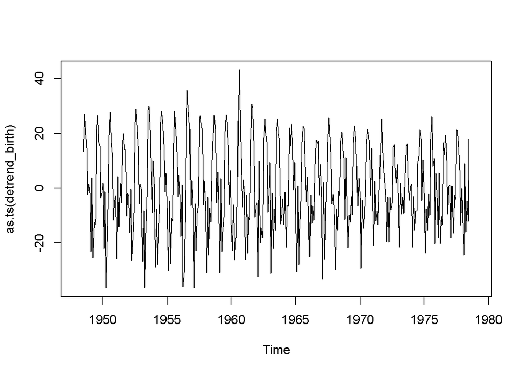

## Data Decomposition

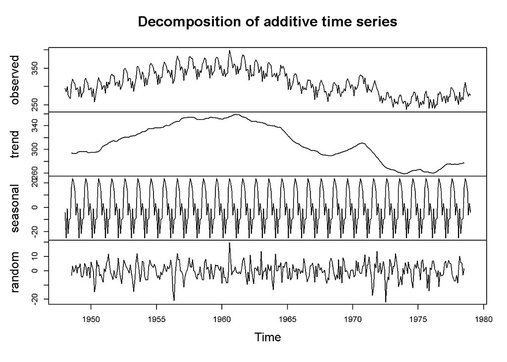

Overall trend appears to be decreasing over time as stated above previously. Seasonality does seem to exist in the late summer/early fall months. Residuals appear to be random and are not significantly increasing over time.

## Regression

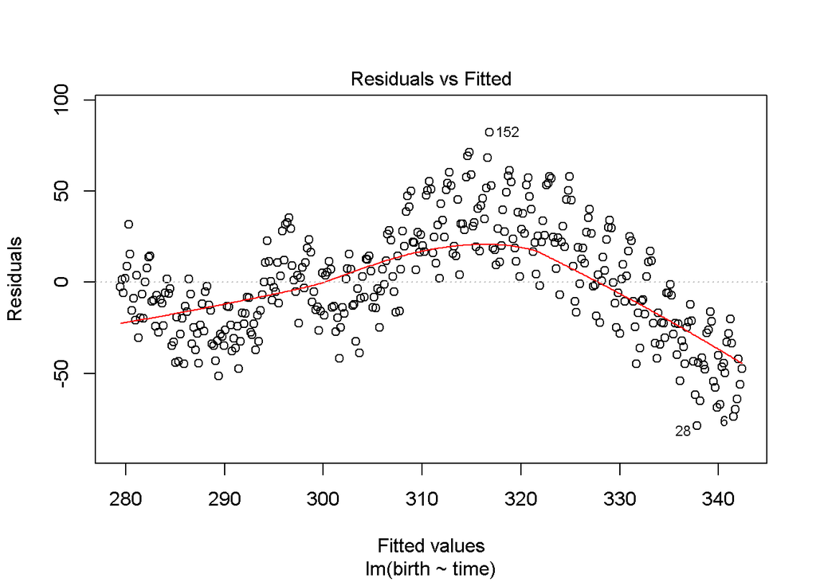

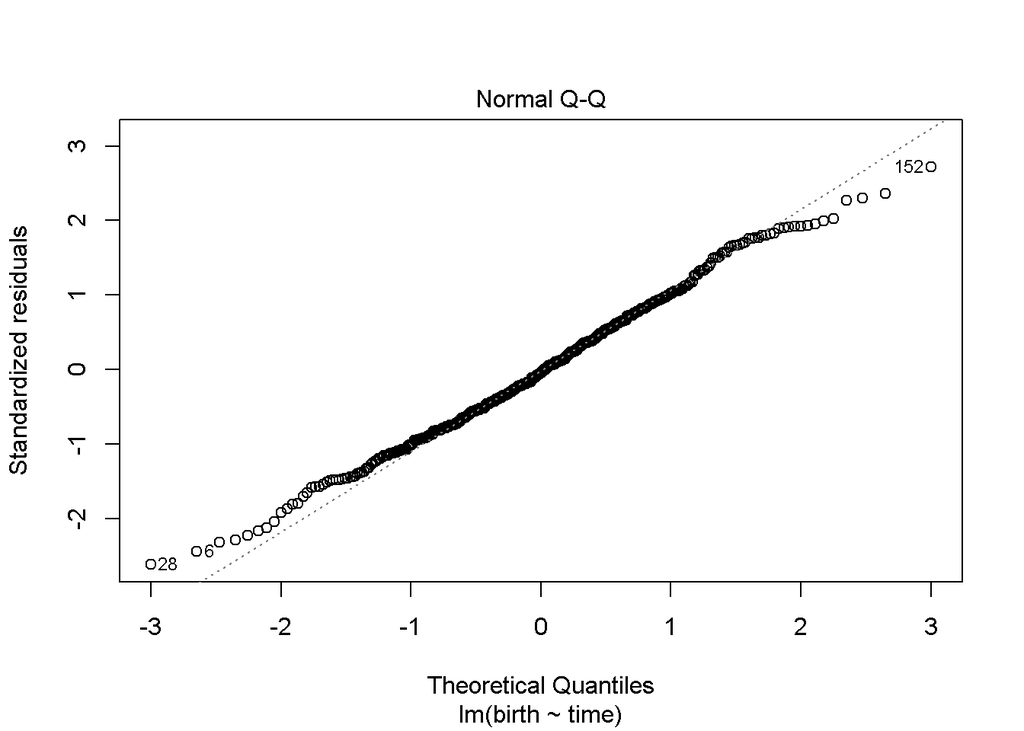

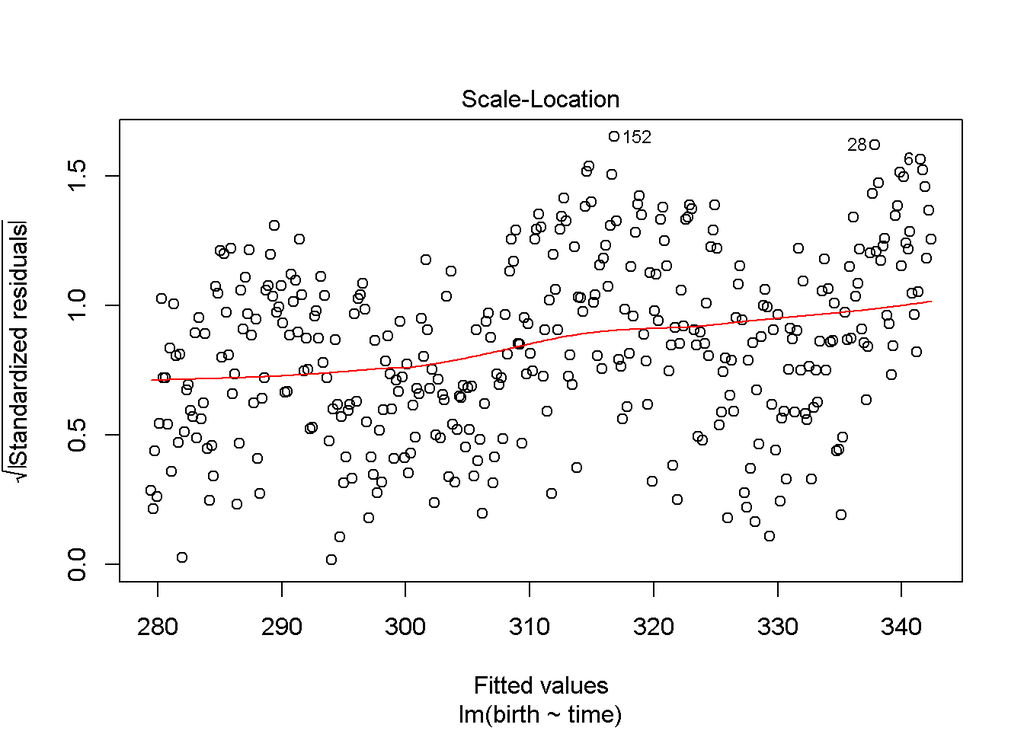

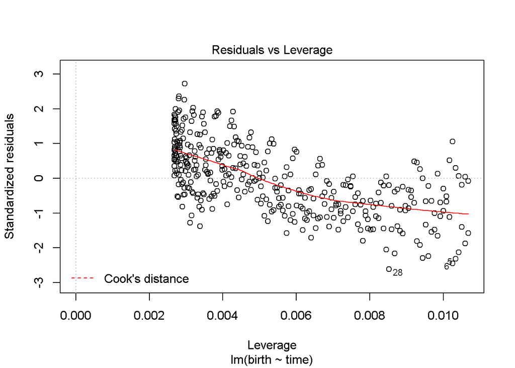

```
## (Intercept)        time
## 4297.311078   -2.030253
```

```
##
## Call:
## lm(formula = birth ~ time)
##
## Residuals:
##     Min      1Q  Median      3Q     Max
## -78.810 -22.411  -1.172  21.602  82.170
##
## Coefficients:
##              Estimate Std. Error t value Pr(>|t|)
## (Intercept) 4297.3111   342.2257   12.56   <2e-16 ***
## time          -2.0303     0.1743  -11.65   <2e-16 ***
## ---
## Signif. codes:  0 '***' 0.001 '**' 0.01 '*' 0.05 '.' 0.1 ' ' 1
##
## Residual standard error: 30.2 on 371 degrees of freedom
## Multiple R-squared:  0.2678, Adjusted R-squared:  0.2658
## F-statistic: 135.7 on 1 and 371 DF,  p-value: < 2.2e-16
```

## ARMA/ARIMA

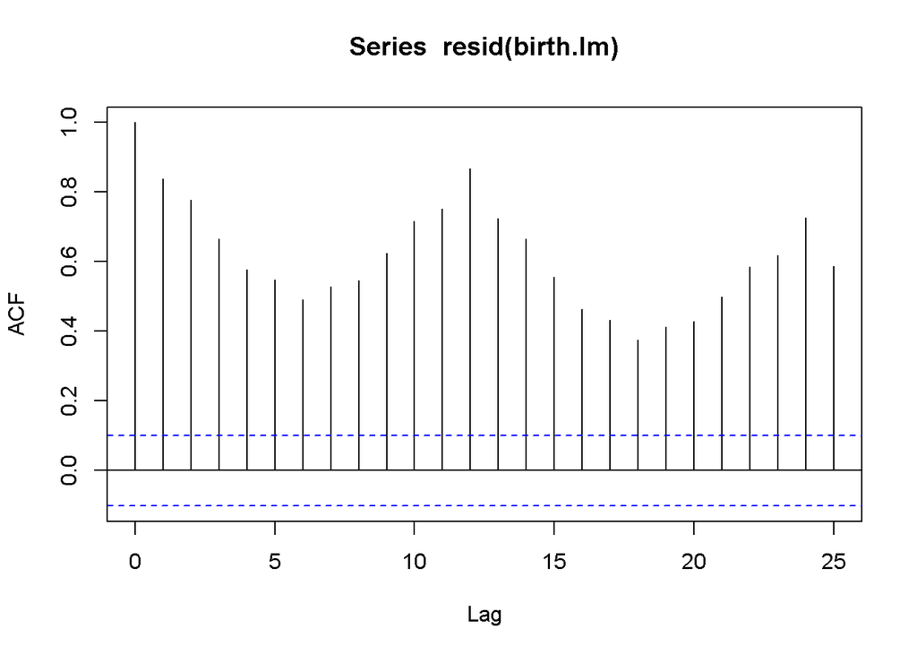

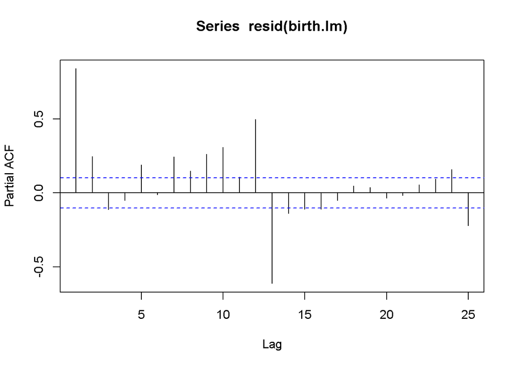

Observing the ACF plot, it does not appear to be stationary and seasonality exists that needs to be accounted for in the model

## Model Diagnostics

```
##
## Call:
## arima(x = birth, order = c(0, 1, 2), seasonal = list(order = c(1, 1, 1), period = 12),
##     method = "ML")
##
## Coefficients:
##           ma1      ma2    sar1     sma1
##       -0.3984  -0.1631  0.1017  -0.8433
## s.e.   0.0512   0.0486  0.0713   0.0477
##
## sigma^2 estimated as 45.58:  log likelihood = -1204.93,  aic = 2419.86
```

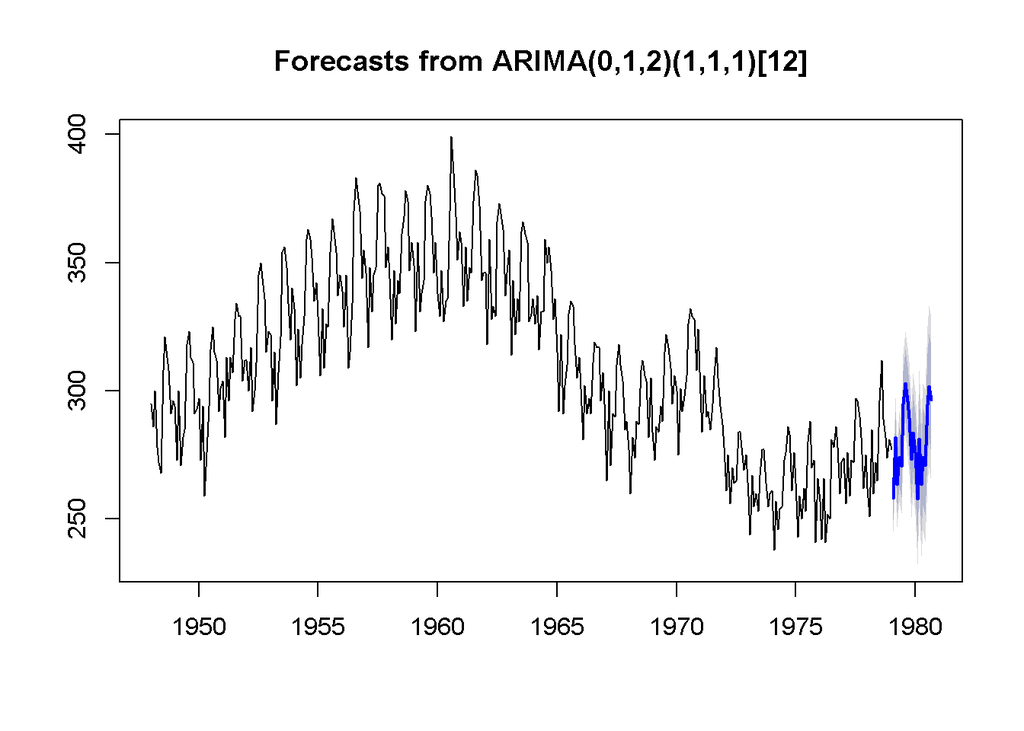

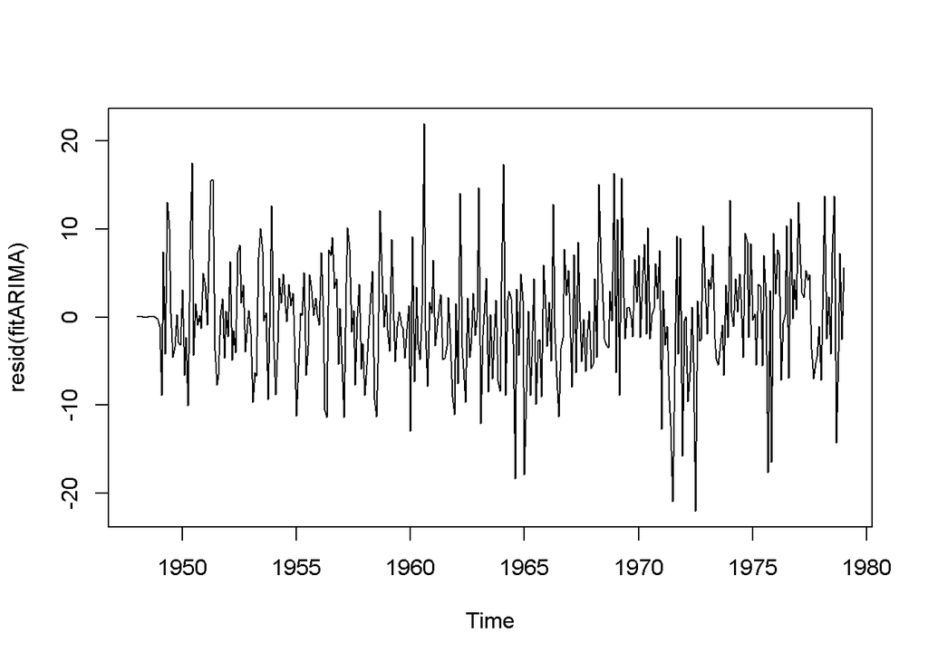

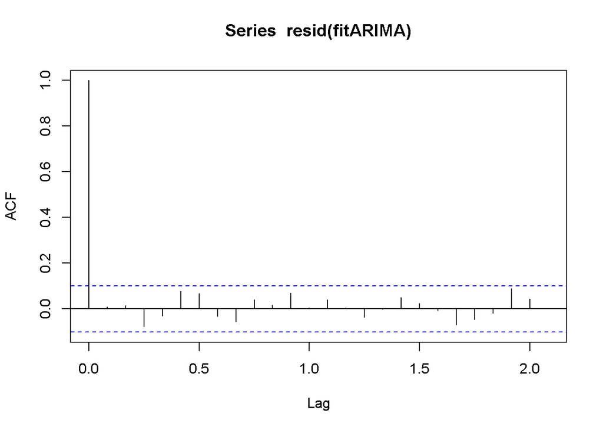